# Volesti tutorial

# Rounding

We generate skinny polytopes, in particular skinny cubes of the form $\{x=(x_1,\dots,x_d)\ |\ x_1\leq 100, x_1\geq-100,x_i\leq 1,x_i\geq-1,x_i\in \mathbb{R}, \text{ for } i=2,\dots,d\}$.

Our random walks perform poorly on those polytopes especially as the dimension increases. Note that if we use the `CDHR` walk here is cheating since we take advantage of the instance structure.

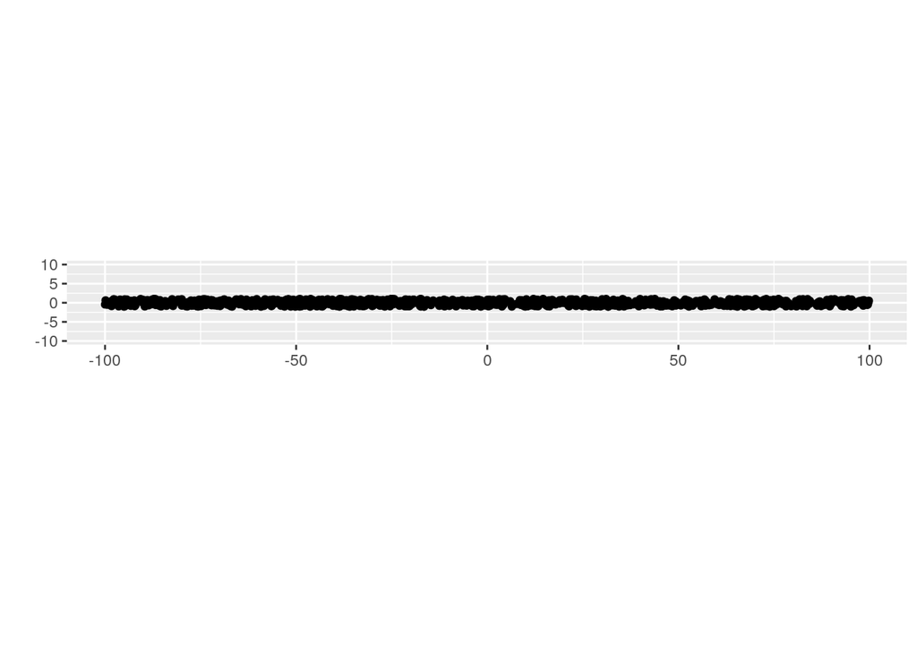

```r
library(ggplot2)

P = GenSkinnyCube(2)
points1 = sample_points(P, WalkType = "CDHR", N=1000)
ggplot(data.frame(x = c(points1[1,]), y = c(points1[2,])), aes(x=x,
y=y)) + geom_point() +labs(x =" ", y = " ")+coord_fixed(ylim =
c(-10,10))
```

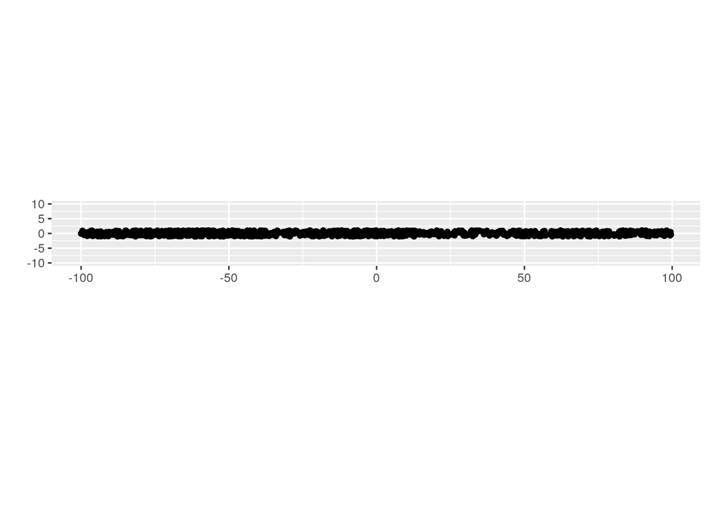

```r
points1 = sample_points(P, WalkType = "RDHR", N=1000)
ggplot(data.frame(x = c(points1[1,]), y = c(points1[2,])), aes(x=x,
y=y)) + geom_point() +labs(x =" ", y = " ")+coord_fixed(ylim =
c(-10,10))
```

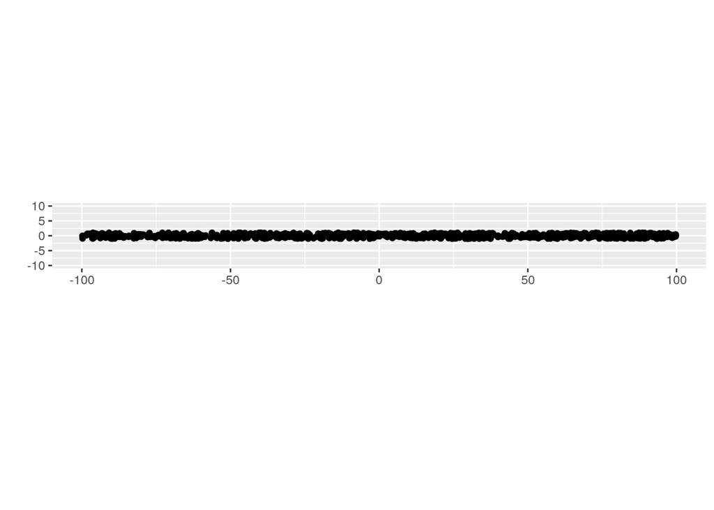

```r
P = GenSkinnyCube(10)
points1 = sample_points(P, WalkType = "CDHR", N=1000)
ggplot(data.frame(x = c(points1[1,]), y = c(points1[2,])), aes(x=x,
y=y)) + geom_point() +labs(x =" ", y = " ")+coord_fixed(xlim =
c(-100,100), ylim = c(-10,10))
```